# Course 4 - Exploratory Data Analysis - Week 2 - Notes

Greg Foletta

2019-10-29

# Lattice Plotting System

Useful for plotting high-dimensional data. Doesn’t have atwo phase plotting - everything is in one call.

## Functions

- `xyplot()` for scatterplots.
- `bwplot()` for boxplots.
- `histogram()` for histograms.
- `stripplot()` like a boxplot but with actual points.
- `dotplot()` to plot does on ‘violin strings’.
- `splom()` for a scatterplot matrix - like `pairs()` in the base system.
- `levelplot()`, `contourplot()` for plotting ‘image’ data.

The functions generally takes a formula with some conditioning variables. e.g.

```
# We have <y-axis ~ x-axis> on the left.
# f and g are conditioning variables - they are optional.
xyplot(y ~ x | f * g, data)
```

If no data frame is supplied, it will look in the parent environment frame for those variables.

## Simple Plot

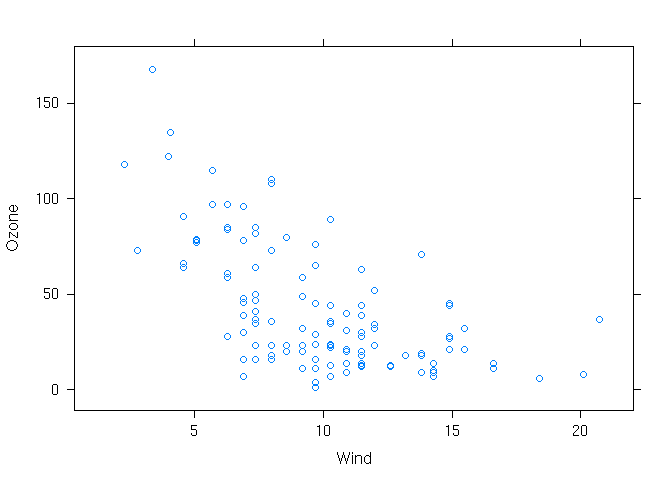

```r
library(lattice)
library(datasets)
xyplot(Ozone ~ Wind, airquality)
```

Can separate into different plots based on a categorical variable:

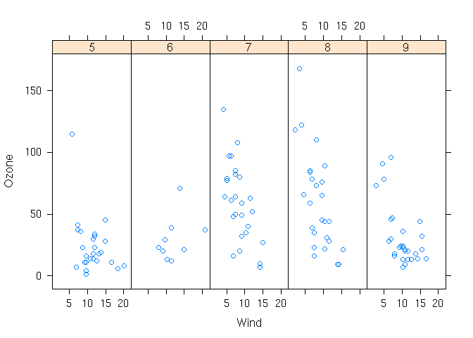

```r
airquality <- airquality %>% mutate(Month = as.factor(Month))
xyplot(Ozone ~ Wind | Month, airquality, layout = c(5,1))
```

## Behaviour

The lattice functions behave differently from base in one important way:

- Base plots data directly to a graphics device.
- Lattice returns an object of class `trellis`.
- The print methods for lattice functions actually plot the data on the graphics device.
- On the command line, the trellis objects are auto-printed.

## Panel Functions

The lattice functions have a panel function which controls what happens inside each panel of the plot. It comes with default functions, but these can be overridden.

The panel functions receive x/y coordinates of the data points in their panel along with optional arguments.

Each panel represents a subset of the data based on the conditioning variable passed to the function.

We can plot with two panels:

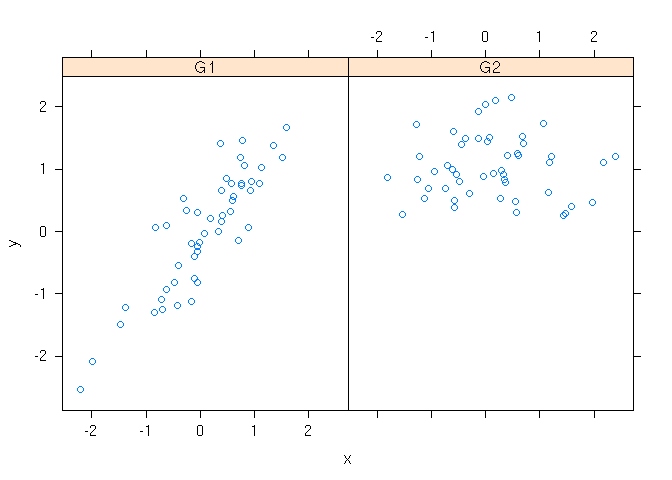

```r
set.seed(1)
raw <- tibble(
    x = rnorm(100),
    f = rep(0:1, each = 50),
    y = x + f - f * x + rnorm(100, sd = 0.5)
) %>%
    mutate(f = factor(f, labels = c('G1', 'G2')))

xyplot(y ~ x | f, raw, layout = c(2,1))
```

Now we provide a custom panel function. It first calls the default panel function, then adds a horizontal line at the median.

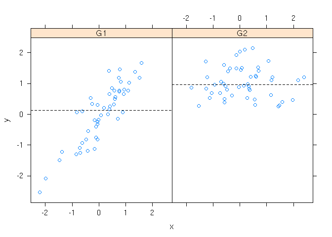

```r
xyplot(y ~ x | f, data = raw, panel = function(x,y, ...) {
    panel.xyplot(x,y,...)
    panel.abline(h = median(y), lty = 2)
})
```

We could also add a regression line. The `col` arugment specifies the colour.

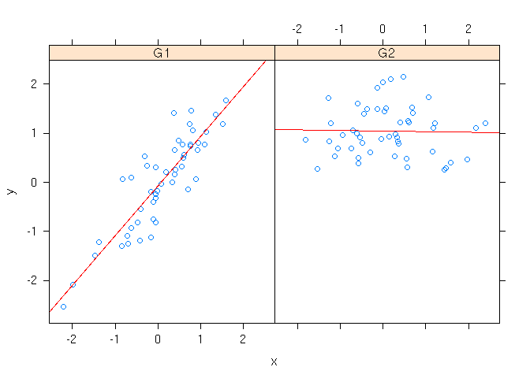

```r
xyplot(y ~ x | f, data = raw, panel = function(x,y, ...) {
    panel.xyplot(x,y,...)
    panel.lmline(x, y, col = 2)
})
```

## Summary

- Single function call.
- Aspects like margins and spacing are automatically handled.
- Ideal for creating plots where the same plot is viewed under many conditions.
- Panel functions are used to customise what is plotted in each panel.

# ggplot2

An implementation of *Grammar of Graphics* by Leland Wilkinson. Written by Hadley Wickham.

> … the grammar tells us that a statistical graphic is a **mapping** from the data to **aesthetic** attributes (colour, shape, size) of **geometric** objects (points, lines). The plot may also contain statistical transformations of the data, and is drawn on a specific coordinate system.

## Basics

The `qplot()` function works much like `plot()` in base. Looks for data in a data frame, or parent environment. Plots are made up of *aesthetics* and *geoms*.

`ggplot()` is the core function and very flexible for doing things `qplot()` cannot do.

The components are:

- A data frame.
- Aesthetic mappings: how data are mapped to colour, size.
- Geoms: geometric objects like points, lines, shapes.
- Facets: for conditional plots.
- Stats: statistical transformations like binning, quantiles, smoothing.
- Scales: what scale an aesthetic map uses.
- Coordinate system.

## Outliers

If you use `+ ylim()`, the outlier will be missing. If you use `+ coord_cartesian(ylim = c(min, max))`, the outlier will be included.